# Predicting Insurance Loss Using Supervised Machine Learning

Author

Alicia Helfrich, Olivia Gomez, and Akbar Naqvi

Published

May 3, 2024

# 1 Project Overview

## 1.1 Introduction

The Patient Protection and Affordable Care Act (ACA), passed in 2010, increased access to health insurance coverage for over 20 million Americans. Yet in 2022, over 25 million Americans still did not have health insurance.[^1] Being uninsured has been shown to lead to poorer health outcomes, limited preventative care, and increased risk of mortality.[^2] Uninsurance is also associated with poor economic outcomes and increases general costs for employers, taxpayers, health systems, and the general public.[^3] For example, uncompensated care for those without insurance averaged over $42 billion between 2015 and 2017.[^4]

Losing insurance can happen for a multitude of reasons, such as job loss or a change in eligibility for public insurance programs. However, getting people re-enrolled in insurance can be difficult due to lack of knowledge of available programs and financial assistance, high cost of insurance, and availability (e.g. coverage offered through employment).[^5] Due to the high social and economic costs associated with being uninsured, state and federal governments, non-profit organizations, and other interested stakeholders have launched campaigns to raise awareness on financial assistance programs, tax credits, state-based Marketplace exchanges, and Medicaid eligibility.[^6] Given that the uninsured population is made up of over 25 million people, targeting campaigns can save taxpayer dollars and increase the effectiveness of the programs.

Given the negative consequences of insurances loss and the costs associated with re-enrolling individuals in insurance, we sought to develop a predictive model that would assist government in targeting and anticipating individuals that may be most as risk of losing their insurance. If effective, such a predictive model can help state and federal policymakers and other interested stakeholders target outreach and enrollment activities, and intelligently allocate limited resources.

## 1.2 Methodology

We decided to develop a supervised machine learning model to predict the likelihood that someone may lose health insurance over the course of the year. Based on available literature and subject matter expertise, we know that uninsurance can be associated with characteristics such as geography, employment status, wealth, and demographics. Therefore, much of our analysis focused on high-quality data sets that contained some of these useful predictors.

## 1.3 Data Sources

There were two key data sets that were utilized in our analysis: the Survey of Income and Program Participation and Medicaid Eligibility statistics.

Given the negative consequences of insurances loss and the costs associated with re-enrolling individuals in insurance, we sought to develop a predictive model that would assist government in targeting and anticipating individuals that may be most as risk of losing their insurance. If effective, such a predictive model can help state and federal policymakers and other interested stakeholders target outreach and enrollment activities.

### 1.3.1 Survey of Income and Program Participation

The Survey of Income and Program Participation (SIPP) is an extensive survey conducted by the U.S. Census Bureau. It contains data on income, labor force participation, social program participation and eligibility, and general demographic characteristics. We are using the SIPP given its breadth, detail, and inclusion of health insurance status. We are using data from the year 2018, as we wanted to use data from before the COVID-19 pandemic. We chose to use 2018 versus 2019 due to limited observations in the 2019 data set.

Survey participants provide data for each month in the preceding calendar year at the time of the interview. Because of this detail, observations are on the person-month level, meaning there could be 12 observations for a single person for a given variable. Household-level questions are copied across all members of the household.

#### 1.3.1.1 Library Loadings

```r
library(tidyverse)
library(haven)
library(data.table)
library(readxl)
library(lubridate)
library(vcd)
library(caret)
library(tidymodels)
library(tune)
library(survey)
library(vip)
```

#### 1.3.1.2 Reading in Data

```r
#initial pull of data
data_2018 <- fread("data/pu2018.csv",
                   sep = "|",
                   showProgress = TRUE) %>%
            select(-starts_with("A"))


names(data_2018) <- toupper(names(data_2018))
#Make sure all the column names are upper-case
```

#### 1.3.1.3 Creating Unique Respondent IDs

SIPP data is divided into annual “panels” with sub “waves”, and sub “sample groups”. Each observation in the data set represents a particular individual during a month. In order to analyze a loss or gain in insurance over the course of a year, we needed to create a unique identifier for each respondent. This was done through a combination of the SSUID, which was a subgroup number unique within a particular annual data, and PNUM, which was unique within each SSUID. The combination of SSUID and PNUM allowed us to assess insurance loss for each respondent and then eventually group observations by the individual.

```r
data_2018 <- data_2018 %>%
   #make unique ID for each respondent
  mutate(unique_id = paste(SSUID,PNUM))
```

#### 1.3.1.4 Creating our outcome variable “insurance_gap”

The SIPP doesn’t have an explicit variable that indicates if someone lost insurance throughout the calendar year. Therefore, we needed to use available data to generate a variable for “insurance_gap”, which acted as our outcome variable. The insurance_gap variable is a boolean field, where “1” means that they had insurance the prior month and then didn’t the following. A “0” would signify that someone either didn’t have insurance for those two consecutive months, did have insurance, or gained insurance after not having it.

The process for creating this variable is detailed below:

```r
#create a separate tibble that will eventually be joined back to SIPP data
#only bringing in the details needed to calculate insurance loss - participant ID, month, and insurance status
#Insurance status is captured by "RHLTHMTH"

  lost_insurance_detail <- data_2018 %>%

    select(SPANEL,SSUID,SWAVE,PNUM,MONTHCODE,RHLTHMTH) %>%
    mutate(unique_id = paste(SSUID,PNUM))

#creating variables to assess if someone lost insurance from one month to the next
lost_insurance_prep <- lost_insurance_detail %>%

  #sort observations so that it is in order of individuals and then in in chronological order
  arrange(unique_id,MONTHCODE) %>%
  group_by(unique_id) %>%
    mutate(

      #recode health insurance field to be a new "no_insurance"
      no_insurance = case_when(
        RHLTHMTH == 2 ~ 1, #had no coverage whatsoever
        RHLTHMTH == 1 ~ 0 #had coverage
      ),

      #create field of "no_insurance_last_month" for each observation
      no_insurance_last_month = lag(no_insurance),

      #create variable subtracting no_insurance and no_insurance last month
      # values will = 1 when they had insurance last month,  but didn't this month
      lost_insurance = no_insurance - no_insurance_last_month,
      insurance_gap = case_when(
        lost_insurance > 0  ~ 1,
        lost_insurance <= 0 ~ 0),

      #rename month columns to make a clean cross-tabluar table
      month = case_when(
        MONTHCODE == 1 ~ "January",
        MONTHCODE == 2 ~ "February",
        MONTHCODE == 3 ~ "March",
        MONTHCODE == 4 ~ "April",
        MONTHCODE == 5 ~ "May",
        MONTHCODE == 6 ~ "June",
        MONTHCODE == 7 ~ "July",
        MONTHCODE == 8 ~ "August",
        MONTHCODE == 9 ~ "September",
        MONTHCODE == 10 ~ "October",
        MONTHCODE == 11 ~ "November",
        MONTHCODE == 12 ~ "December")
    )

      #create cross tabular table displaying a unique list of participants and
      #a "1" or a "0" in each month column to denote if they lost insurance last month
      insurance_gap <-  lost_insurance_prep %>%
        pivot_wider(
      id_cols = unique_id,
      names_from = month,
      values_from = insurance_gap) %>%

        #add a new binary variable that counts the months someone lost insurance during the month
        mutate(
       month_of_insurance_loss = sum(January,February, March, April, May, June, July, August, September, October, November, December, na.rm = TRUE),

       #create dummy variable for "1" if someone lost insurance during the year
       # "0" if they didn't experience a new loss during the year
        insurance_gap = case_when(
          month_of_insurance_loss > 0 ~ 1,
          month_of_insurance_loss < 1 ~ 0)
        )

    #update the original data frame so that it is organized by unique individuals
      #The final dataset will keep demographic variables, etc from January/the first observation
      #But will add in the months that someone lost coverage and the new "insurance_gap" variable
      data_2018_final <- insurance_gap %>%
        left_join(
          x = .,
          y = data_2018,
          by = "unique_id"
        ) %>%
         distinct(unique_id, .keep_all = TRUE)
```

### 1.3.2 State Medicaid Eligibility Data

Many individuals are insured with Medicaid, which can vary in terms of eligibility requirements across states and can change substantially over the course of the year. For this reason, we believed that the particular states’ frequency with which eligibility checks are made, and other local Medicaid policy specifications, could be a useful predictor of insurance loss. (For example, three states allow for 12-month continuous eligibility, while others conduct periodic eligibility checks before the standard annual renewal date. To account for some of these variations, we have created several indicator variables.[^7][^8]. We compiled a small data set that summarizes these characteristics and joined them to our main SIPP data based on the respondent’s state of residence at the beginning of the year.

```r
# tibble of indicator variables for state eligibility rules of interest
state_eligibility_rules <- read_excel("data/state_eligibility_rules.xlsx")

# create new variables representing the type of eligibility rule that applies to the
  #state of residence of the respondent (as of January 2018)
data_2018_final <-  data_2018_final %>%
  mutate( state_id = TEHC_ST) %>%
        left_join(
          x = .,
          y = state_eligibility_rules,
          by = "state_id"
        )
```

## 1.4 Exploratory Data Analysis

### 1.4.1 Outcome Variable Exploration

As mentioned, we created the outcome variable insurance_gap, which indicates if the respondent lost coverage at any point over the course of a year. In looking at the distribution of this variable we found that only 696 out of over 63,000 individuals were estimated to have lost insurance, representing around 1% of the sample population.

```r
summary(data_2018_final$insurance_gap)
```

```
   Min. 1st Qu.  Median    Mean 3rd Qu.    Max.
0.00000 0.00000 0.00000 0.01089 0.00000 1.00000
```

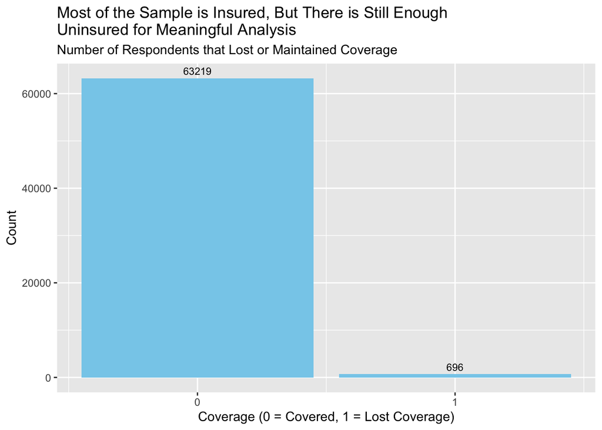

```r
data_2018_final %>%
  ggplot(mapping = aes(x = insurance_gap)) +
  geom_bar(fill = "skyblue") +
  geom_text(stat = 'count', aes(label = after_stat(count)), vjust = -0.5, color = "black", size = 3) +
  scale_x_continuous(breaks = c(0, 1)) +
  labs(title = "Most of the Sample is Insured, But There is Still Enough \nUninsured for Meaningful Analysis", y = "Count", x = "Coverage (0 = Covered, 1 = Lost Coverage)",
       subtitle = "Number of Respondents that Lost or Maintained Coverage")
```

Given how low this metric appeared, decided to conduct a nonparametric binomial test to understand whether this estimate was statistically different than the insurance loss rate we would expect for the US population. Based on findings from this exercise, we adjusted our analysis accordingly.

The null hypothesis for our binomial test was that the proportion of individuals within our sample that lost insurance throughout the course of the year is equal to the rate of insurance loss for the broader population. The alternative was that these two proportions would not be equal. In order to properly conduct this test, we needed to understand the true rate of insurance loss for the US population over the course of a year to serve as our p value. Unfortunately, while there is much literature on how many individuals are uninsured within the course of a year, there are not readily available numbers on who many people experience the new loss of insurance across a year. Therefore, we needed to make several assumptions based on the information available.

We were able to find that 13% of middle-aged individuals that had Medicaid in January had experienced some kind of a gap in coverage throughout the year.[^9] Using this as an anchor, we would expect that this proportion would be lower for the general population. Those on private insurance, which make up most cases (as we show below), are more likely to be in sector that is at lower risk of turnover(and thus loss of private insurance), or be more likely to have resources to purchase personal insurance in the event of losing their job. We decided to assume, based on limited data, that the true probability of losing insurance for our population of interest would be 10%.

```r
# Count the number of successes (individuals who lost insurance)
successes <- data_2018_final %>%
  #those that lost insurance
  filter(insurance_gap == 1) %>%
  #those that had it in January
  filter(RHLTHMTH == 1) %>%
  nrow()

# Total number of observations (sample size)
total <- data_2018_final %>%
  filter(insurance_gap == 1 | insurance_gap == 0) %>%
   filter(RHLTHMTH == 1) %>%
  nrow()

# Hypothesized probability of success (under the null hypothesis)
p_null <- 0.1

# Perform the exact binomial test
binom_test <- binom.test(x = successes, n = total, p = p_null,conf.level = .9)

# Print the results
print(binom_test)
```

```
    Exact binomial test

data:  successes and total
number of successes = 633, number of trials = 56674, p-value < 2.2e-16
alternative hypothesis: true probability of success is not equal to 0.1
90 percent confidence interval:
 0.01045279 0.01192293
sample estimates:
probability of success
            0.01116914
```

These results raised several flags for us, and we took actions to mitigate this. It is possible that the raw, unweighted sample is under representing demographic groups that would be most likely to lose insurance. For instance, it is possible that the raw, unweighted sample is under representing demographic groups that would be most likely to loss insurance, and therefore deflating this metric. We have opted to utilizing replicate weights available by Census within our model fitting process to try and account for this discrepancy.

Secondly, with a low rate of insurance loss within our sample, we understand that there may be a high likelihood of overfitting or bias our model. We will assess our model against several error metrics, to interpret the utility of our model and within the model selection phase. This is expanded on within our model development section further.

### 1.4.2 Examining Variable Related to Insurance Loss

We sought to examine several variables that we believe have a relevance to health insurance loss: food insecurity and private vs. public health insurance.

#### 1.4.2.1 Food Security Score

Food security can be an important predictor of uninsurance. One study found that compared to people who are food secure, individuals with food insecurity “postpone needed medical care and medications more often, use more emergency and inpatient care, and have higher care expenditures by as much as 121%.[^10]

The below visualization shows the distribution of food security in our sample. We found that the large majority of respondents identified as having high food security. A simplistic inference could be that any “risks” associated with low food security and uninsurance were less present in our sample population.

```r
predictor_eda <- data_2018_final %>%
  select(
    EORIGIN, ECITIZEN,#country of origin
         EHOWWELL,ERACE,ESEX,#English proficiency,race,sex
         RFOODS, #food security
         RDIS, #disability status
         EMS, #marital status
  ) %>%
  summary()

predictor_eda
```

```
  unique_id            EORIGIN         ECITIZEN        EHOWWELL
 Length:63915       Min.   :1.000   Min.   :1.000   Min.   :1.00
 Class :character   1st Qu.:2.000   1st Qu.:1.000   1st Qu.:1.00
 Mode  :character   Median :2.000   Median :1.000   Median :1.00
                    Mean   :1.811   Mean   :1.065   Mean   :1.57
                    3rd Qu.:2.000   3rd Qu.:1.000   3rd Qu.:2.00
                    Max.   :2.000   Max.   :2.000   Max.   :4.00
                                                    NA's   :53085
     ERACE            ESEX           RFOODS           RDIS
 Min.   :1.000   Min.   :1.000   Min.   :1.000   Min.   :1.000
 1st Qu.:1.000   1st Qu.:1.000   1st Qu.:1.000   1st Qu.:2.000
 Median :1.000   Median :2.000   Median :1.000   Median :2.000
 Mean   :1.365   Mean   :1.516   Mean   :1.156   Mean   :1.789
 3rd Qu.:1.000   3rd Qu.:2.000   3rd Qu.:1.000   3rd Qu.:2.000
 Max.   :4.000   Max.   :2.000   Max.   :3.000   Max.   :2.000
                                                 NA's   :429
      EMS
 Min.   :1.000
 1st Qu.:1.000
 Median :3.000
 Mean   :3.085
 3rd Qu.:6.000
 Max.   :6.000
 NA's   :11757
```

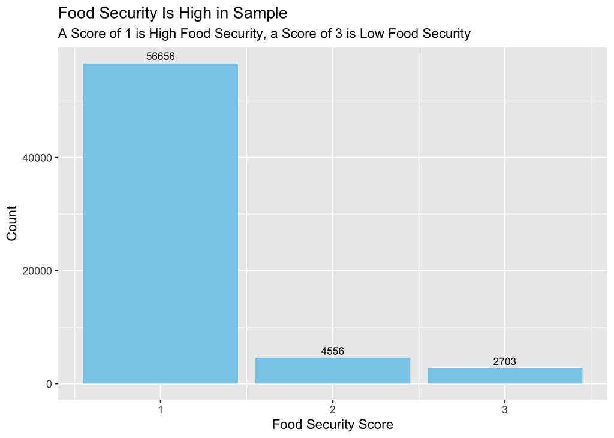

```r
data_2018_final %>%
  group_by(RFOODS) %>%
  ggplot(mapping = aes(x = RFOODS)) +
  geom_bar(fill = "skyblue") +
  geom_text(stat = 'count', aes(label = after_stat(count)), vjust = -0.5, color = "black", size = 3) +
  scale_x_continuous(breaks = c(1, 2, 3)) +
  labs(title = "Food Security Is High in Sample", subtitle = "A Score of 1 is High Food Security, a Score of 3 is Low Food Security", y = "Count", x = "Food Security Score")
```

#### 1.4.2.2 Insurance Type Coverage

Given the focus on health insurance, we were also interested to see the distribution of coverage types in this sample. We found that around 2/3rd of the insured population in the US had private health insurance through an employer. Given how many in our sample rely on their job for insurance, We could infer or hypothesize that employment variables within the data set may play heavily into the predictors of “insurance_gap”.

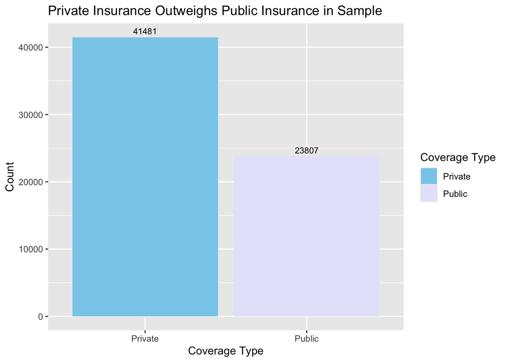

```r
# Count occurrences of RPRIMTH equal to 1 for each unique ID
private_counts <- data_2018_final %>%
  filter(RPRIMTH == 1) %>%
  count(unique_id, name = "private_count") %>%
  nrow()

# Count occurrences of RPUBMTH equal to 1 for each unique ID
public_counts <- data_2018_final %>%
  filter(RPUBMTH == 1) %>%
  count(unique_id, name = "public_count") %>%
  nrow()

counts_df <- data.frame(Coverage_Type = c("Private", "Public"),
                        Count = c(private_counts, public_counts))

ggplot(counts_df, aes(x = Coverage_Type, y = Count, fill = Coverage_Type)) +
  geom_bar(stat = "identity") +
  geom_text(aes(label = Count), vjust = -0.5, color = "black", size = 3) +
  labs(x = "Coverage Type", y = "Count") +
  scale_fill_manual(values = c("Private" = "skyblue", "Public" = "lavender")) +
  labs(title = "Private Insurance Outweighs Public Insurance in Sample", fill = "Coverage Type")
```

### 1.4.3 Missingness & Imputation Methods

In addition to exploring several variable of interest, we sought to understand missingness within our sample.

The U.S. Census Bureau utilized and published documentation around their own data imputation sources. Given the extensive expertise of the U.S. Census Bureau within the SIPP data, we relied heavily on their work to mitigate systematically missing data that would have tampered with our analysis results. Census imputation protocols were as follows, based on the assumption that data are missing at random within subgroups of the population. The imputation methods used are:

1. Model-based Imputation: A process that involves estimating sequential models that predict values for a missing variable, conditional on demographic data, all other topic flags earnings data within the IRS and SSA.
2. Sequential hot-deck imputation: This method matches a record with missing data to that of a donor with similar background characteristics

We observed, after reviewing documentation, that there were over 600 variables that were missing data entirely (whether it be due to separate universes or another cause), we dropped all variables with complete missingness.

```r
# dropping variables where every value is missing
vars_with_missing <- colnames(data_2018_final)[apply(data_2018_final, 2, function(x) any(is.na(x)))]
vars_with_all_missing <- sapply(data_2018_final, function(col) all(is.na(col)))
vars_to_drop <- names(vars_with_all_missing)[vars_with_all_missing]

data_2018_final <- data_2018_final %>%
select(-one_of(vars_to_drop))
```

## 1.5 Data Preparation for Model Creation

After exploratory analysis, we made several decisions to refine our data so that it would be in the best position to create a robust model. Namely, the SIPP dataset comes with a large, computationally-costly, set of variables. We focused on taking out variables that would be either least likelihood to improve predictions or most likely to cause overfitting or bias.

### 1.5.1 Identifying Zero Variance Predictors

First, we focused on removing variables that had almost zero variance, which would limit their utility in predicting “insurance_gap” and add substantial computational costs. We compiled a list of zero variance columns through the code below:

```r
near_zero_cols <- names(data_2018_final)[nearZeroVar(x = data_2018_final, freqCut = 99.5/.5)]
```

### 1.5.2 Identifying Highly Associated Variables

After identifying near-zero variance columns, we sought to remove predictors that were either perfectly correlated with insurance_gap or that would likely lead to overfitting or bias of our predictions (e.g., in-depth questions around specific public or private health insurance, uninsurance, etc). We utilized logical reasoning to sift through the hundreds of health insurance or employment questions that we believed would corrupt our model.

#### 1.5.2.1 Removing Perfectly Correlated Variables

Secondly, we built a correlation matrix to identify variables that were perfectly correlated with insurance_gap. Below, we added in variables that either based on literature or subject matter knowledge that we believed would be most likely to be highly correlated with the variable.

Please note: although we are, in the case below, investigating the relationship between two categorical variables (versus continuous), we found the exercise useful for exploratory purposes and for balancing the computational costs of other tests of association.

```r
# evaluating correlation
potential_predictors <- data_2018_final %>%
  ungroup() %>%
  select(-all_of(near_zero_cols),
         # all employment data
         starts_with("EJB"),

         # medicaid eligibility
         starts_with("elig_"),

         #adult wellbeing
         starts_with("EAWB"),

         #food security
         starts_with("EFOOD"),

         #demographics
         TAGE_EHC,#Age
         RFAMKIND,#family size
         RFRELU18,RHNUM65OVER,
         EORIGIN,EMS,ECITIZEN,#country of origin
         EHOWWELL,ERACE,ESEX,#engligh proficiency,race,sex
         RFOODS, #food security
         RDIS, #disability status
         EMS, #marital status

         #personal finances
         TDEBT_AST, #personal debt
         THINC_AST,#household income
         TNETWORTH, #net worth

         #location
         EAWBSAFE, #safety
         EVOUCHER, #housing voucher
         TEHC_ST, #state
         TMETRO_INTV, #metropolitan area
  )

#narrow list to numeric predictors to allow for correlation matrix
potential_predictors_num <- potential_predictors %>%
  select(where(is.numeric))

# Calculate correlation matrix
correlation_matrix <- cor(potential_predictors_num,use = "pairwise.complete.obs")


# Filter correlations to only show associations with insurance_gap
insurance_gap_correlations <- correlation_matrix["insurance_gap", ]

# Sort correlations in descending order, to later filer
significant_correlations <-  insurance_gap_correlations[order(abs(insurance_gap_correlations),decreasing = TRUE)]

#Take the top 200 correlations to include within the model
significant_correlations <-
    significant_correlations[abs(significant_correlations) == 1]

# Convert the vector created in the prior step to a tibble
significant_correlations <- enframe(significant_correlations,name = "variable",value = "correlation_level")

#commenting out because of lengthy result
#view(significant_correlations)
```

There were 8 variables that were found to be perfectly associated with insurance_gap, namely dealing with employment metrics. Many of the variables, removed in the code below, related to employment/unemployment spells.

#### 1.5.2.2 Removing Other Variable at Risk of Overfitting or Bias

In addition to removing perfectly correlated variables with insurance_gap, we also decided to remove other variables that could cause overfitting of our model such as supplemental questions regarding health insurance, and other identified employment variables.

Below, you may find the code that was utilized to prepare our final data set, removing zero variance variables and highly correlated variables:

```r
data_2018_final_rf <- data_2018_final %>%
  ungroup() %>%
  #remove zero variance variables
  select(-all_of(near_zero_cols),

  ## dropping health insurance variables
  -starts_with("EHI1WHO"),
   -starts_with("EHICOST"),
   -starts_with("EHIUNT"),
   -starts_with("EHLTHSAV"),
   -starts_with("ELIFEMNYN"),
   -starts_with("ELIFE"),
   -starts_with("EMCPART"),
   -starts_with("EMC_BMONTH"),
   -starts_with("EMDEND"),
   -starts_with("EMDEXCH"),
   -starts_with("EMDMTH"),
   -starts_with("EMD"),
   -starts_with("EMHI")
   -starts_with("EMILIEND"),
   -starts_with("EMLMTH"),
   -starts_with("EMLUNT"),
   -starts_with("EML_"),
   -starts_with("ENO"),
   -starts_with("EMO"),
   -starts_with("EOTH"),
   -starts_with("EOT_"),
   -starts_with("EOWN"),
   -starts_with("EPR"),
   -starts_with("EVA"),
    -starts_with("EWH"),
    -starts_with("EYNO"),
   -starts_with("RCDMTH"),
   -starts_with("RDIRECTANN"),
   -starts_with("REMPLOYANN"),
   -starts_with("RHI"),
   -starts_with("RMARKTPLACE"),
   -starts_with("RMC_"),
   -starts_with("RMD_"),
   -starts_with("RML_"),
   -starts_with("RMEDCARE"),
   -starts_with("RNONHH"),
   -starts_with("ROTHCOVMTH"),
   -starts_with("ROT_CONTFLG"),
   -starts_with("RPR"),
   -starts_with("RPRI"),
   -starts_with("RPUB"),
   -starts_with("RTRIC"),
   -starts_with("RVACARE"),
   -starts_with("TCVAL_MED"),
   -starts_with("TCVAL_STD"),
   -starts_with("TDIS10_CFLG"),
   -starts_with("TDIS1AMT"),
   -starts_with("TDIS1_CFLG"),
   -starts_with("TDOCNUM"),
   -starts_with("TDOCNUM_"),
   -starts_with("TFVAL_"),
   -starts_with("THIPAY"),
   -starts_with("TLIFE"),
   -starts_with("TVA5"),
   -starts_with("TVIS"),

  # Dropping selected employment variables
  -EJB4_EMONTH,
  -RJB4_CFLG,
-EJB4_ENDWK,
-EJB4_STRTJAN,
-EJB4_STARTWK,
-EJB3_OINCB,
-EJB4_JOBID,
-TJB4_HOURLY1,
-month_of_insurance_loss,
-EMHLOAN2SITE,
-EJB4_CEXPAY,
-EJB3_AWOPSM3,
-EJB3_AWPCFL3,
-EJB3_AWOPSW3,
-EJB3_AWOPEW3,
-TJB4_CXAMT,
-EJB4_CEXPAY,
-EJB3_AWOPSM3,
-EJB3_AWPCFL3,
-EJB3_AWOPSW3,
-EJB3_AWOPEW3,
-TJB4_CXAMT,
-EJB4_INCPB,
-EJB4_CEXPAY,
-EJB4_PFTLOSS,
-EJB3_AWOPSM3,
-EJB3_AWPCFL3,
-EJB3_AWOPSW3,
-EJB3_AWOPEW3,
-TJB4_EMPB,
-TBSJ5VAL,
-TBSJ5DEBTVAL,
-TJB4_CXAMT,
-TJB4_PRFTB,
          insurance_gap) %>%

  #convert insurance gap to be a factor for random forest modeling
  mutate(insurance_gap = factor(insurance_gap))
```

### 1.5.3 Adding Survey Weights to Our Data

The U.S. Census Bureau provides two types of weights to help with analysis: replicate weights and longitudinal weights. Longitudinal weights compensate for panel attrition and post-stratification adjustments to make weighted sample totals confirm to population totals for key variables. Since we are only using data for a single month, we attempted to use person-level replicate weights, which allow a single sample to simulate multiple samples, thus generating more standard errors that maintain the normal properties of standard errors while retaining the complex survey design.

```r
#read in the weighting files from SIPP website
rw_2018 <- fread("data/rw2018.csv", sep = "|", showProgress = TRUE) %>%
  select(SSUID, PNUM, repwgt0, monthcode) %>%
  mutate(unique_id = paste(SSUID,PNUM))


#filter by January weights

rw_2018 <- rw_2018 %>%
  filter(monthcode == 1)

#Make sure all the column names are upper
names(rw_2018) <- toupper(names(rw_2018))

names(rw_2018) <- c(names(rw_2018)[names(rw_2018) != "UNIQUE_ID"], "unique_id")

#Merge primary data and replicate weights on SSUID, PNUM, MONTHCODE, SPANEL, and SWAVE
data_2018_final_rf <- inner_join(data_2018_final_rf, rw_2018, by = "unique_id")
```

Please note: we had several options for when to apply weights to our data set. We found mixed research on when to apply weighting to our data set (before preprocessing, during preprocessing, and model fitting). Ultimately, we decided to apply weights during model fitting for several reasons. Our understanding is that weighting during model fitting cuts down on computational costs. This helped us mitigate challenges we consistently experienced with computer processing bandwidth.

## 1.6 Model Development and Implementation

For our supervised machine learning model, we decided to develop a random forest model. This algorithm was selected for several reasons. First, given the level of nuance that goes into obtaining or losing insurance (e.g., Medicaid varying from state to state), we felt that the model could capture underlying patterns in our data with a high level of accuracy. Additionally, our team experienced a number of hurdles when running computationally heavy code. While a random forest can be costly, it can be highly effective with relatively little hyper parameter tuning, and provides options for parallelization.

### 1.6.1 Creating Training/Testing and Cross Validation

```r
set.seed(20240430)

# create a split object
data_split <- initial_split(data = data_2018_final_rf, prop = 0.75)

# create the training and testing data
training <- training(x = data_split)
testing  <- testing(x = data_split)

# making less folds to reduce computational cost
rf_folds <- vfold_cv(data = training, v = 5)
```

### 1.6.2 Feature Engineering

Given the advantages of a random forest model, we kept feature engineering to a minimum, namely removing nominal/categorical variables that had little predictive advantage and conducing basic data imputation.

```r
#pre process data
recipe <- recipe(insurance_gap ~., training) %>%
  update_role(unique_id,SSUID.x, SSUID.y, PNUM.x, PNUM.y,
              ENJ_LAYOTYP,
              EJB4_BSLRYB,TJB3_GAMT1,TSUR10AMT,TJB3_WKLY1,TJB1_OTHER3,
              EJB2_AWOPSM3,EJB2_AWOPEM3, EJB2_AWPCFL3, EJB2_AWOPSW3,EJB2_AWOPEW3,
              EJB2_AWOPRE3,TJB2_HOURLY3,TJB3_ANNSAL2,
              TJB3_IMBMIC,TJB3_OTHER1,
              new_role = "id") %>%
  step_rm(has_role("id")) %>%
  step_impute_median(all_numeric_predictors()) %>%
  step_impute_mode(all_nominal_predictors())
```

### 1.6.3 Hyperparameter Tuning

In terms of hyperparameter tuning, we tested only the trees parameter given computational costs, but assigned min_n and mtry based on best practices for the amount of variables and observations within each fold.

```r
# creating random forest tuning grid
rf_grid <- grid_regular(
  trees(range = c(100, 500)), levels = 2)

  # we selected these hyperparameters with tuning and cross validation
model <- rand_forest(
  trees = tune(),

  # taking roughly the square root of number of variables
  mtry = 37,

   #taking 5-10% of total observations in a fold/in testing to avoid over fitting
  min_n = 300,
) %>%

  #setting parallelization to reduce computational cost
  set_mode(mode = "classification") |>
  set_engine(
    engine = "ranger",
    importance = "impurity",
    num.threads = 4
  )

workflow <- workflow() %>%
  add_recipe(recipe) %>%
  add_model(model)
```

### 1.6.4 Fitting Our Model

```r
resamples <- workflow %>%
  tune_grid(
    resamples = rf_folds,
    grid = rf_grid,
    metrics = metric_set(recall, precision),
    #weight by monthly replication variable
    weights = REPWGT0
  )

results <- resamples %>%
  collect_metrics()

results
```

```
# A tibble: 4 × 7
  trees .metric   .estimator  mean     n  std_err .config
  <int> <chr>     <chr>      <dbl> <int>    <dbl> <chr>
1   100 precision binary     0.990     5 0.000357 Preprocessor1_Model1
2   100 recall    binary     1         5 0        Preprocessor1_Model1
3   500 precision binary     0.990     5 0.000357 Preprocessor1_Model2
4   500 recall    binary     1         5 0        Preprocessor1_Model2
```

```r
model_best <- resamples %>%
 select_best()
```

### 1.6.5 Interpreting Error Metrics

We decided to prioritize two error metrics in selecting our best mode: precision and recall. We did this for several reasons. The first is that, given that our outcome “event” only occurred around 1% of the time, we wanted to prioritize the effectiveness of identified positive instances through assessing the proportion of correctly predicted positive instances, as well as the proportion of positive instances that were predicted out of all true positives.

Additionally, we felt that these metrics had a more relevant policy application. Focusing on the effectiveness of the true positive rates ensures that those that actually are most likely to lose insurance are identified by the model. In the event that someone is identified as falsely negative, it is possible that that efforts for outreach to mitigate uninsurance would be 1) inefficient in terms of costs, and 2) harmful in not reaching those that are most at at risk of harm due to uninsurance.

### 1.6.6 Analyzing Results and Evaluating Final Model

Using our finally fitted model, we applied the best model to our testing data:

```r
# extract parameters of the best model
final_workflow <-
  workflow %>%
  finalize_workflow(model_best)

# apply the best specifications to the other "folds" of the data
final_model_fit <-
  final_workflow %>%
  parsnip::fit(data = training)
```

```r
predictions <- bind_cols(
  testing,
  predict(
      object = final_model_fit, new_data = testing)
  )
```

In order to assess the true performance of the model against the testing data, we constructed a confusion matrix.

```r
# Create the confusion matrix

confusion_matrix <- conf_mat(predictions, truth = insurance_gap, estimate = .pred_class)


confusion_matrix
```

```
          Truth
Prediction     0     1
         0 15520   194
         1     0     0
```

The model correctly identified all true negatives. However, it did not identify any true positives, and had 194 false negatives. Unfortunately, this would seem to confirm our concerns that there is an imbalance in classes within our data set. We offer some methods of improving the prediction of insurance loss in future analysis.

### 1.6.7 Variable Importance

Although our model results were mixed, we sought to investigate the variable importance that the model used to predict insurance loss.

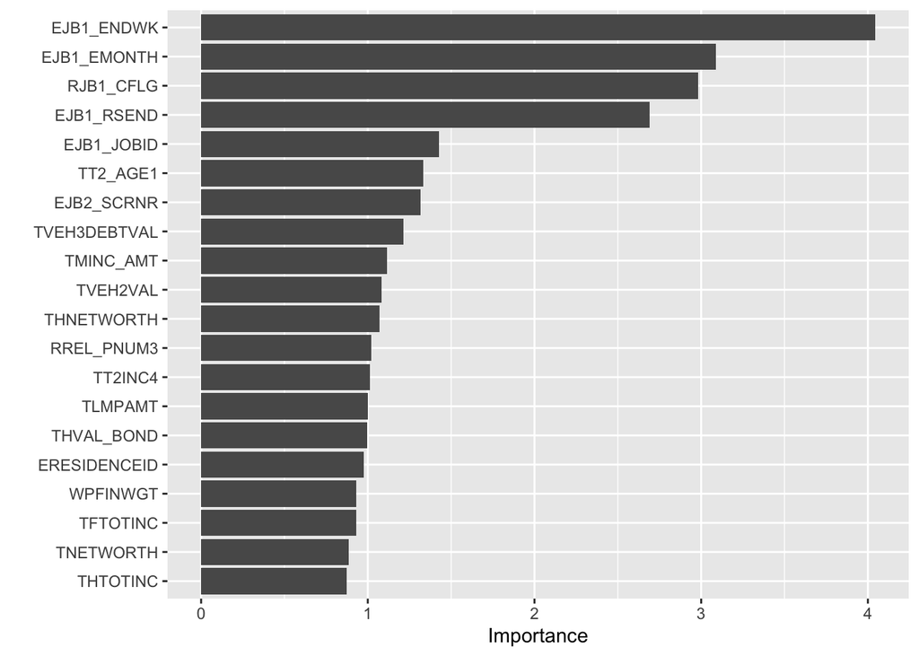

```r
final_model_fit %>%
  extract_fit_parsnip() %>%
  vip(num_features = 20)
```

## 1.7 Conclusions

This model, if improved, could help inform policymakers at the state, federal, and local levels where to focus fiscal and legislative priorities to improve health insurance coverage and the overall public health of communities. By being able to predict a citizen’s loss of coverage, and understanding what comprises the uninsured population, programs could target the root causes of health insurance loss, like job loss, health inequities, and poverty. While stopgaps do exist for people who lose employment, and thus insurance, the coverage is expensive and poor in many places. Improving insurance coverage, and anticipating those most likely to lose insurance can ensure intelligent allocation of resources for unemployed populations could reduce overall healthcare spending and improve the health and well-being of communities.

This model could also inform state Medicaid agencies efforts to reduce unnecessary losses in coverage. As the Medicaid program is considered a safety net program, ensuring that everyone that is eligible for coverage has access is important. State agencies could target populations that have many uninsured individuals, as an example to how this model could be utilized.

## 1.8 Limitations

There were a number of limitations to our analysis that should influence the interpretation of our results:

- **Low instance of insurance loss within sample puts model at risk of over fitting.** Ultimately, the low instance of insurance_gap within our sample would warrant further investigation to ensure the available data within the SIPP is capturing loss accurately. It is possible that another data set may have more valid health-specific information information.
- **Participant recall bias.** Related to the above, SIPP data reports on monthly units, but often collects data at a quarterly or annual frequency. This would require individuals to recite, by memory, their economic or health insurance status by month. This inherently could result in inaccurate reporting of insurance status and undermine the utility of our model.
- **Changes in external factors that influence insurance loss limit generalizability.** There have been many macroeconomic or policy level changes that change how likely someone might be to losing insurance. For example, COVID-19 resulted in substantial changes to the economy and to health policy. During the pandemic many states were unable to adjust eligibility requirements for Medicaid, and recently have begun adjusting policy. These adjustments are already reporting many individuals losing health coverage. These eligibility requirements would play a large role in how many people lose insurance - but ultimately would not be integrated into our model. Updated data, both on eligibility and on an individual level, would need to be utilized to apply this model in a current setting.
- **Sample population changes throughout sampling period.** For time constraints, demographic features of participants as of January were utilized to generate predictions on insurance loss. However, there are many attributes of a respondent that are subject to change and that could influence insurance loss. For example: an individual who lost Medicaid coverage because they moved to a new state with stricter Medicaid requirements, or an individual who became divorced and lost their spouses’ insurance coverage. The omission of this data throughout our analysis means that useful patterns may not have been captured within our model, and therefore could hinder performance within other environments.

Ultimately, these factors, among others, should be considered prior to expanding on our model or utilizing to understanding broader, generalization predictions. At this point in time, we would not recommend the utilization of our model to inform policy decisions.

### 1.8.1 Sources

Brooks, T., Roygardner, L., Artiga, S., Pham, O., & Dolan, R. (2020). *Medicaid and CHIP Eligibility, Enrollment, and Cost Sharing Policies as of January 2020: Findings from a 50-State Survey*. Kaiser Family Foundation (KFF). https://www.kff.org/report-section/medicaid-and-chip-eligibility-enrollment-and-cost-sharing-policies-as-of-january-2020-findings-from-a-50-state-survey-tables/

Berchick, E. (2018). *Who Are the Uninsured?* U.S. Census Bureau. https://www.census.gov/library/stories/2018/09/who-are-the-uninsured.html

Buettgens, M. (2023). *Ensuring Continuous Eligibility for Medicaid and CHIP: Coverage and Cost Impacts for Adults*. The Commonwealth Fund. https://www.commonwealthfund.org/publications/issue-briefs/2023/sep/ensuring-continuous-eligibility-medicaid-impacts-adults

Coughlin, T. A., Samuel-Jakubos, H., & Garfield, R. (2021). *Sources of Payment for Uncompensated Care for the Uninsured*. Kaiser Family Foundation (KFF). https://www.kff.org/uninsured/issue-brief/sources-of-payment-for-uncompensated-care-for-the-uninsured/

Davis, K. (2003). *In the Literature: The Costs and Consequences of Being Uninsured*. https://www.commonwealthfund.org/sites/default/files/documents/___media_files_publications_in_the_literature_2003_jun_the_costs_and_consequences_of_being_uninsured_davis_consequences_itl_663_pdf.pdf

Lukens, G. & Sharer, B. (2021). *Closing Medicaid Coverage Gap Would Help Diverse Group and Narrow Racial Disparities*. The Center on Budget and Policy Priorities (CBPP). https://www.cbpp.org/research/health/closing-medicaid-coverage-gap-would-help-diverse-group-and-narrow-racial#_ftn6

Schwab, R., Swindle, R., & Giovannelli, J. (2022). *State-Based Marketplace Outreach Strategies for Boosting Health Plan Enrollment of the Uninsured*. The Commonwealth Fund. https://www.commonwealthfund.org/publications/issue-briefs/2022/oct/state-based-outreach-boosting-enrollment-uninsured

Sonik, R. A. (2019). Health Insurance and Food Insecurity: Sparking a Potential Virtuous Cycle. *American Journal of Public Health*, *109*(9), 1163–1165. https://doi.org/10.2105/AJPH.2019.305252

*Survey of Income and Program Participation.* (2018). U.S. Census Bureau, retrieved from https://www.census.gov/programs-surveys/sipp/data/datasets/2018-data/2018.html

*The Consequences of Being Uninsured*. (2014). National Immigration Law Center. https://www.nilc.org/wp-content/uploads/2015/11/consequences-of-being-uninsured-2014-08.pdf

Tolbert, J., Drake, P., & Damico, A. (2023). *Key Facts about the Uninsured Population*. Kaiser Family Foundation (KFF). https://www.kff.org/uninsured/issue-brief/key-facts-about-the-uninsured-population/

## Footnotes

[^1]: Tolbert, 2023
[^2]: National Immigration Law Center, 2003
[^3]: Davis, 2023
[^4]: Coughlin, 2021
[^5]: Tolbert, 2023
[^6]: Schwab, 2022
[^7]: Buettgens, 2023
[^8]: Brooks, 2020
[^9]: Lukens, 2021
[^10]: Sonik, 2019
[^11]: Berchick, 2018
[^12]: Berchick, 2018